# SI/LI Fire Selection

Kristin Braziunas

## Purpose

The purpose of this script is to identify overlapping fire perimeters using data from MTBS (fires 1983 or later) and Yellowstone and Grand Teton National Parks. Excluded prescribed fires and fires with an interval of less than 5 years (unlikely to be a “forest” reburn because insufficient time to recover after first fire). Selected fires with a reburn interval of < 30 years (short-interval fire, SI). Final fires were selected in which the second fire occurred after 1988, because Tania Schoennagel’s dataset provides ample observations of SI fires where the second fire was in 1988.

```r
# load libraries
library(rgdal)
library(sp)
library(raster)
library(rgeos)
library(sf)
library(dplyr)
library(openxlsx)
```

## 1-4. Initial SI fire selection

Sections 1-4 of this script resulted in an initial set of potential SI fires. These fires were subsequently screened by hand and with ancillary burn severity data from MTBS to identify high-priority areas based on repeat high-severity fire, forest recovery in between fires, sufficient patch size of moderate to high-severity fire, and ease of access.

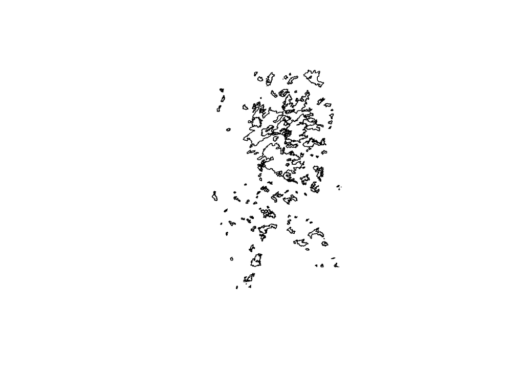

```r
#####
# 1. Read in fire perimeter shapefiles
#####

### mtbs for conus
mtbs.in <- st_read("data/MTBS/mtbs_perimeter_data/mtbs_perims_DD.shp")

# add year based on ignition date
mtbs.in$Year <- as.numeric(format(mtbs.in$Ig_Date,'%Y'))

### gye outline
gye.in <- st_read("data/nr_gye/GYE_outline.shp")

### historical data from yellowstone, only 1958 or later
# The input file geodatabase
ygdb <- "data/YELL/yell_fire_history.gdb"

# List all feature classes in a file geodatabase
subset(ogrDrivers(), grepl("GDB", name))
fc_list <- ogrListLayers(ygdb)
print(fc_list)

# Read the feature class
yell.in <- st_read(dsn=ygdb,layer="yell_fire_perimeters") %>%
  filter(YEAR >= 1958 & YEAR <= 1983) # exclude anything with > 30 yr FRI and anything not in MTBS database

### historical data from grand teton, only 1958 or later
# The input file geodatabase
ggdb <- "data/GRTE/GRTE_FireHistory.gdb"

# List all feature classes in a file geodatabase
subset(ogrDrivers(), grepl("GDB", name))
fc_list <- ogrListLayers(ggdb)
print(fc_list)

# Read the feature class
grte.in <- st_read(dsn=ggdb,layer="WF_Perimeters_flat_ply") %>%
  filter(FireCalendarYear >= 1958 & FireCalendarYear <= 1983) # exclude anything with > 30 yr FRI and anything not in MTBS database


#####
# 2. subset to GYE, combine shapefiles, identify intersecting fires
#####

### first crop mtbs
st_crs(gye.in) == st_crs(mtbs.in) # false

# transform gye to mtbs CRS
gye.trans <- st_transform(gye.in, crs = st_crs(mtbs.in))
st_crs(gye.trans) == st_crs(mtbs.in)

# crop mtbs
mtbs.crop <- st_crop(mtbs.in,gye.trans) %>% # gives rectangle
  st_intersection(gye.trans)

# check
plot(st_geometry(mtbs.crop)) # looks good
```

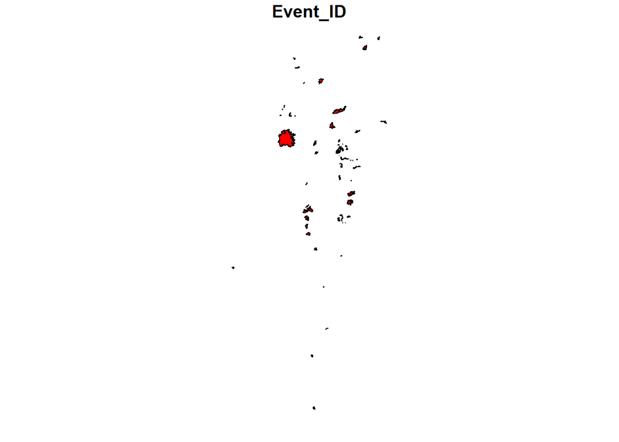

```r
# transform mtbs to utm coordinates
mtbs.gye <- st_transform(mtbs.crop, crs = st_crs(gye.in))

### combine, mtbs, yell, and grte fires
str(mtbs.gye)
st_crs(mtbs.gye)

# prep mtbs
mtbs.sm <- mtbs.gye %>%
  mutate(BurnBndHa = BurnBndAc/2.471, Event_ID = as.character(Event_ID), Incid_Name=as.character(Incid_Name),
         Incid_Type = as.character(Incid_Type), Map_Prog=as.character(Map_Prog), Ig_Date = as.character(Ig_Date)) %>%
  dplyr::select(Event_ID,Incid_Name,Incid_Type,Map_Prog,BurnBndHa,Ig_Date,Year,geometry)

# prep yell.in
st_crs(yell.in) # good

yell.sm <- yell.in %>%
  mutate(BurnBndHa = ACRES_CALC/2.471, Event_ID = as.character(Y_FIRE_ID), Incid_Name = as.character(Y_FIRE_NAM),
         Map_Prog = as.character(AREA_NAME)) %>%
  rename(Incid_Type = SPEC_CAUSE, Ig_Date = DISC_DATE, Year=YEAR, geometry=Shape) %>%
  dplyr::select(Event_ID,Incid_Name,Incid_Type,Map_Prog,BurnBndHa,Ig_Date,Year,geometry)

# prep grte.in
st_crs(grte.in) # needs transformation

grte.sm <- grte.in %>%
  st_transform(crs = st_crs(mtbs.gye)) %>%
  mutate(BurnBndHa = GISAcres/2.471,
         Ig_Date = FireCalendarYear, Event_ID = as.character(UniqueFireID), Incid_Name = as.character(IncidentName),
         Incid_Type = as.character(FeatureCategory), Map_Prog = as.character(ReportingUnitID)) %>%
  rename(Year = FireCalendarYear, geometry=Shape) %>%
  dplyr::select(Event_ID,Incid_Name,Incid_Type,Map_Prog,BurnBndHa,Ig_Date,Year,geometry)

# combine
mtbs.sf <- rbind(mtbs.sm,yell.sm,grte.sm)

### identify intersecting fires using sf
mtbs.int <- mtbs.sf %>%
  st_set_precision(1e5) %>%
  st_intersection() %>%
  filter(n.overlaps > 1) # filter only overlapping

# add area of overlap
mtbs.int$area <- st_area(mtbs.int) %>% units::set_units(ha)

#####
# 3. criteria for selecting fires
#####

# address potential edge issues
mtbs.sel <- st_buffer(st_buffer(mtbs.int, -0.001),0.001)

# areas with 3 overlap (triple burn)
mtbs.sel %>%
  filter(n.overlaps == 3)

# get first and second fire
# no prescribed fire
# FRI >= 5 years, insufficient time for forest recovery
# FRI <= 30 years, definition of short-interval
fire.select <- st_intersection(mtbs.sf, mtbs.sel) %>%
  st_collection_extract() %>% # fix issues with polygons
  filter(Incid_Type != "Prescribed Fire",
         Incid_Type.1 != "Prescribed Fire") %>%  # remove prescribed fire
  mutate(FRI = abs(Year - Year.1)) %>%
  filter(FRI >= 5 & FRI <=30) %>% # FRI >= 10 years
  filter(Year >= 1984 | Year.1 >= 1984) %>%  # at least 1 year in mtbs record
  dplyr::select(-origins)


# generate subset with post-88 second fires only, because 1988 fires covered by Schoennagel et al. 2003
fire.select2 <- st_intersection(mtbs.sf, mtbs.sel) %>%
  st_collection_extract() %>% # fix issues with polygons
  filter(Incid_Type != "Prescribed Fire",
         Incid_Type.1 != "Prescribed Fire") %>%  # remove prescribed fire
  mutate(FRI = abs(Year - Year.1)) %>%
  filter(FRI >= 5 & FRI <= 30) %>% # FRI >= 10 years
  filter(Year > 1988 | Year.1 > 1988) %>%  # at least 1 year in mtbs record
  dplyr::select(-origins)

#####
# 4. identify first and second fires
#####

# If Year is first fire, set to 0, else 1
fire.select$fire_order <- ifelse(fire.select$Year < fire.select$Year.1, 0, 1)
fire.select2$fire_order <- ifelse(fire.select2$Year < fire.select2$Year.1, 0, 1)

fire1 <- ifelse(fire.select$fire_order == 0,
               as.character(fire.select$Event_ID),
               as.character(fire.select$Event_ID.1))
fire2 <- ifelse(fire.select$fire_order == 1,
               as.character(fire.select$Event_ID),
               as.character(fire.select$Event_ID.1))

# now subset mtbs records
# subsetting original shapefile
mtbs.fire1 <- mtbs.sf %>%
  filter(Event_ID %in% c(fire1))

mtbs.fire2 <- mtbs.sf %>%
  filter(Event_ID %in% c(fire2))

### write out - commented out for Rmd
# st_write(fire.select, "processed_data/fire_selection/fire_intersection.shp", delete_dsn=TRUE)
#
# st_write(fire.select2, "processed_data/fire_selection/fire_intersection_post88.shp", delete_dsn=TRUE)
#
# st_write(mtbs.fire1, "processed_data/fire_selection/fire1.shp", delete_dsn=TRUE)
# st_write(mtbs.fire2, "processed_data/fire_selection/fire2.shp", delete_dsn=TRUE)

# plot reburns
plot(fire.select2[1], col="red")
```

```r
# version for note-taking
fire.df1 <- as.data.frame(fire.select2) %>%
  filter(fire_order==0) %>%
  dplyr::select(c(Event_ID,Incid_Name,Year,Event_ID.1,Incid_Name.1,Year.1,n.overlaps,area,FRI)) %>%
  rename(Event_ID_1 = Event_ID, Incid_Name_1 = Incid_Name, Year_1 = Year,
         Event_ID_2 = Event_ID.1, Incid_Name_2 = Incid_Name.1, Year_2 = Year.1)

fire.df2 <- as.data.frame(fire.select2) %>%
  filter(fire_order==1) %>%
  dplyr::select(c(Event_ID.1,Incid_Name.1,Year.1,Event_ID,Incid_Name,Year,n.overlaps,area,FRI)) %>%
  rename(Event_ID_1 = Event_ID.1, Incid_Name_1 = Incid_Name.1, Year_1 = Year.1,
         Event_ID_2 = Event_ID, Incid_Name_2 = Incid_Name, Year_2 = Year)

### write out - commented out for Rmd
# fire.dfout <- rbind(fire.df1, fire.df2) %>%
#   write.csv("processed_data/fire_selection/fire_intersection_df.csv", row.names=FALSE)
```

## 5. Create master burn severity raster

Section 5 uses a screened subset of fires (`processed_data/fire_intersection_df_notes.csv`) to create a master burn severity raster. Classification cut-offs for unburned, low, moderate, or high (stand-replacing) severity are from Harvey et al. 2016 Ecology (see citation in paper). The final raster includes areas classified as long-interval (4; unburned during first fire, burned as stand-replacing in second), short-interval (8; burned twice as stand-replacing), and moderate to high short-interval (7; burned once as moderate severity and second time and high severity). The moderate to high short-interval areas are used to identify patches where burn severity was at least moderate, for the purpose of selecting plots that were not too close to the edge of a burned patch. This burn severity raster was used to further screen and prioritize fires for sampling in the 2021 field season, as well as for selecting field plot locations.

```r
#####
# 5. Create master raster of stand x stand, long interval
#####

### load initially screened fires based on area of overlap, SI high-severity fire
fire.screened <- read.csv("processed_data/fire_selection/fire_intersection_df_notes.csv") # full set

# read in shapefiles if needed
fire.select <- st_read("processed_data/fire_selection/fire_intersection.shp")
mtbs.fire1 <- st_read("processed_data/fire_selection/fire1.shp")
mtbs.fire2 <- st_read("processed_data/fire_selection/fire2.shp")

### read in all the rasters for these fires
rnames <- tolower(unique(c(as.character(fire.screened$Event_ID_1),as.character(fire.screened$Event_ID_2))))
rnames <- rnames[!rnames %in% c("198117","198152","1974-wygtp-4009","1978-wygtp-8005","1981-wygtp-1903")]

# first get max extent
xmin=-1100000
xmax=-1100000
ymin=2500000
ymax=2500000

for (i in rnames) {
  print(i)

  # read in raster extent
  ext.in <- extent(raster(list.files(paste0("data/MTBS/MTBS_rdnbr/",i), pattern="rdnbr.tif",full.names=TRUE)))

  # get maximum extent
  xmin.new <- (ext.in[1])
  xmax.new <- (ext.in[2])
  ymin.new <- (ext.in[3])
  ymax.new <- (ext.in[4])

  xmin <- min(xmin,xmin.new)
  xmax <- max(xmax,xmax.new)
  ymin <- min(ymin,ymin.new)
  ymax <- max(ymax,ymax.new)

}

# assign maximum extent
ext.out <- extent(xmin,xmax,ymin,ymax)

### helper functions
# function to load, mask classified dnbr
load_dnbr <- function(r) {

  # read in burn boundary
  fire.shp <- st_read(list.files(paste0("data/MTBS/MTBS_rdnbr/",r), pattern="burn_bndy.shp",full.names=TRUE))

  # read in classified dnbr
  dnbr <- raster(list.files(paste0("data/MTBS/MTBS_rdnbr/",r), pattern="dnbr6.tif",full.names=TRUE))

  # mask
  sev <- mask(dnbr,fire.shp)

  names(sev) <- r

  return(sev)

}

# function to load, mask, reclassify rdnbr based on Harvey et al. 2016 cutoffs
reclass_rdnbr <- function(r) {

  # read in burn boundary
  fire.shp <- st_read(list.files(paste0("data/MTBS/MTBS_rdnbr/",r), pattern="burn_bndy.shp",full.names=TRUE))

  # read in rdnbr
  rdnbr <- raster(list.files(paste0("data/MTBS/MTBS_rdnbr/",r), pattern="rdnbr.tif",full.names=TRUE))

  # mask
  rdnbr.mask <- mask(rdnbr, fire.shp)

  # reclassify rdnbr per Harvey et al. 2016
  # 1 for unburned (<0), 2 low (0-288), 3 mod (288-675), 4 stand-replacing (675-2000), 5 too high/outlier (>2000)
  # using rdnbr cutoff of 0 for unburned, to include unburned areas within perimeter that would
  # be better plot pairs due to closer proximity to short-interval, < 0 rdnbr likely unburned
  rdnbr.reclass <- reclassify(rdnbr.mask, matrix(c(-Inf,0,1,0,288,2,288,675,3,675,2000,4,2000,Inf,NA)))

  return(rdnbr.reclass)

}

### read in and reclassify rdnbr rasters
sev.out=raster()

for (j in 1:dim(fire.screened)[1]) {

  print(j)
  fid1 <- tolower(fire.screened[j,]$Event_ID_1)
  fid2 <- tolower(fire.screened[j,]$Event_ID_2)

  # read in reclassified rdnbr for second fire
  sev2 <- extend(reclass_rdnbr(fid2),ext.out)

  # read in reclassified rdnbr for first fire
  # exclude fires not in mtbs record
  if(!fid1 %in% c("198117","198152","1974-wygtp-4009","1978-wygtp-8005","1981-wygtp-1903")) {
    sev1 <- extend(reclass_rdnbr(fid1),ext.out)
    # mask fire 1 only to reburned area
    fire.sub <- mtbs.fire2 %>%
      filter(tolower(Event_ID)==fid2)
    fire.aea <- st_transform(fire.sub, crs = crs(sev1))
    sev1.mask <- mask(sev1,fire.aea)

    # remove unused classes, keep mod and hi
    # 1st fire, keep mod and hi, set low to -5, set unburned and inc greenness to 0, set other to -5
    sev1.class <- reclassify(sev1.mask, matrix(c(-Inf,1.9,0,
                                                 1.9,2.9,-5,
                                                 4.9,5.9,0,
                                                 5.9,Inf,-5)))
  } else {
    # if not in mtbs just mask to reburned area
    fire.sub <- mtbs.fire1 %>%
      filter(tolower(Event_ID)==fid1)
    fire.aea <- st_transform(fire.sub, crs = st_crs(sev2))
    sev1.class <- mask(sev2,fire.aea)
  }

  # 2nd fire, keep mod and hi, set low and to -5
  sev2.class <- reclassify(sev2, matrix(c(-Inf,2.9,-5,
                                          4.9,Inf,-5)))

  sev.temp <- sum(stack(sev1.class,sev2.class),na.rm=TRUE)

  # reclassify for output categories
  # 8 is hi x hi, 7 is hi x mod (any order), 4 is long hi only x unburned short
  sev.reclass <- reclassify(sev.temp, matrix(c(-Inf,3.9,NA,
                                               5.9,6.1,NA)))

  # if multiple reburns for same fire, mask other reburns
  multi.reburns <- fire.screened %>%
    mutate(index = 1:nrow(.)) %>%
    filter(tolower(Event_ID_2) == fid2) %>%
    # exclude focal reburn from masking
    filter(index != j)

  if(dim(multi.reburns)[1]>=1) {
    # mask all other reburns
    print("mask other reburns")
    for(k in 1:dim(multi.reburns)[1]){
      # get fid of reburn
      reburn.fid <- multi.reburns[k,]$Event_ID_1

      # get shapefile of other reburn
      reburn.mask <- mtbs.fire1 %>%
        filter(Event_ID == as.character(reburn.fid)) %>%
        st_transform(crs = crs(sev.reclass))

      # mask severity raster
      sev.reclass <- mask(sev.reclass, reburn.mask, inverse=TRUE)
    }

  }

  # stack on top of other rasters
  sev.out <- stack(sev.out,sev.reclass)

}

### add special case for fires where need LI plots within first fire perimeter
# use dnbr6 unburned category to identify other options
# Maple - N Fork
nfork.fid <- unique(tolower(fire.screened[fire.screened$Incid_Name_1=="NORTH FORK",]$Event_ID_1))
nfork.dnbr <- load_dnbr(nfork.fid)
# mask n fork to outline of maple fire
maple.shp <- mtbs.fire2 %>%
  filter(Incid_Name=="MAPLE") %>%
  st_transform(crs = crs(nfork.dnbr))
nfork.mask <- mask(nfork.dnbr, maple.shp)
# reclassify to unburned or increased greenness only, set these as 0 and everything else NA
# unburned is 1, inc greenness is 5
nfork.unb <- reclassify(nfork.mask, matrix(c(-Inf,0.9,NA,0.9,1.9,0,1.9,4.9,NA,4.9,5.9,0,5.9,Inf,NA)))
# load maple rdnbr, stand-replacing only
maple.fid <- unique(tolower(fire.screened[fire.screened$Incid_Name_2=="MAPLE",]$Event_ID_2))
maple.rdnbr <- reclass_rdnbr(maple.fid)
maple.hi <- reclassify(maple.rdnbr, matrix(c(-Inf,3.9,NA,3.9,4.9,4,4.9,Inf,NA)))
# sum these two
maple.temp <- sum(stack(extend(nfork.unb,ext.out),
                        extend(maple.hi,ext.out)))
# only retain long-interval high severity
maple.reclass <- reclassify(maple.temp, matrix(c(-Inf,3.9,NA)))

# Cygnet - N Fork
cygnet.shp <- mtbs.fire2 %>%
  filter(Incid_Name=="CYGNET") %>%
  st_transform(crs = crs(nfork.dnbr))
nforkc.mask <- mask(nfork.dnbr, cygnet.shp)
# reclassify to unburned or increased greenness only, set these as 0 and everything else NA
# unburned is 1, inc greenness is 5
nforkc.unb <- reclassify(nforkc.mask, matrix(c(-Inf,0.9,NA,0.9,1.9,0,1.9,4.9,NA,4.9,5.9,0,5.9,Inf,NA)))
# load maple rdnbr, stand-replacing only
cygnet.fid <- unique(tolower(fire.screened[fire.screened$Incid_Name_2=="CYGNET",]$Event_ID_2))
cygnet.rdnbr <- reclass_rdnbr(cygnet.fid)
cygnet.hi <- reclassify(cygnet.rdnbr, matrix(c(-Inf,3.9,NA,3.9,4.9,4,4.9,Inf,NA)))
# sum these two
cygnet.temp <- sum(stack(extend(nforkc.unb,ext.out),
                         extend(cygnet.hi,ext.out)))
# only retain long-interval high severity
cygnet.reclass <- reclassify(cygnet.temp, matrix(c(-Inf,3.9,NA)))

# add these to sev.out raster
sev.out <- stack(sev.out, maple.reclass, cygnet.reclass)

### combine all. classes:
# 4 for stand-replacing in 2nd fire only
# 7 for any combo of mod x hi severity
# 8 for stand-replacing double burns (stand-replacing both times)

sev.sum <- max(sev.out,na.rm=TRUE)

# clean up
rm(sev.out)

### write raster - commented out for Rmd
# writeRaster(sev.sum,"processed_data/fire_selection/rdnbr_reburns_all.tif", format="GTiff",overwrite=TRUE)
```

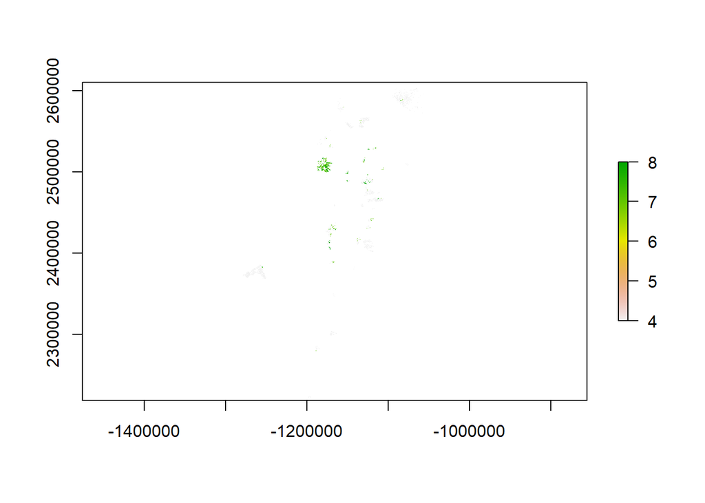

```r
# reload raster if needed
sev.sum <- raster("processed_data/fire_selection/rdnbr_reburns_all.tif")

plot(sev.sum)
```

## 6. Final selected fires

Section 6 of this script loads the final selected list of fires that was sampled in 2021 and creates shapefiles with the final perimeters for fire 1, fire 2, and reburned area.

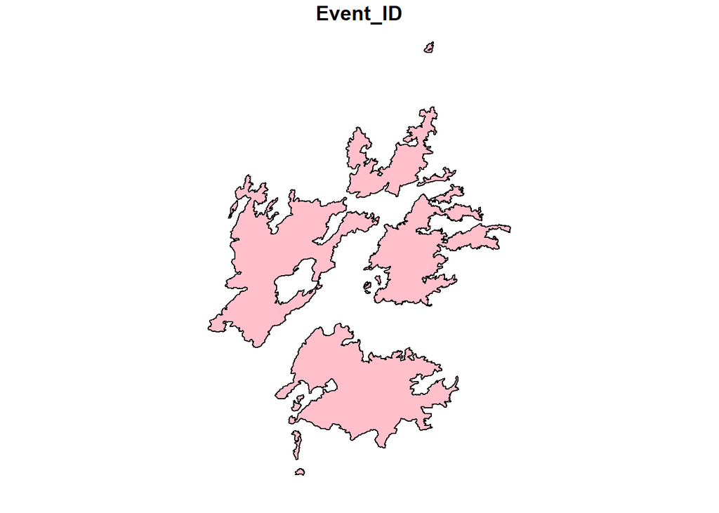

```r
#####
# 6. final sampled fires for 2021 field season
#####

### read in shapefiles if needed
fire.select <- st_read("processed_data/fire_selection/fire_intersection.shp")

mtbs.fire1 <- st_read("processed_data/fire_selection/fire1.shp")
mtbs.fire2 <- st_read("processed_data/fire_selection/fire2.shp")

# read in derby fire perimeter, cut off by gye outline
derby.in <- st_read("data/MTBS/MTBS_rdnbr/mt4559210981020060822/mt4559210981020060822_20060708_20070711_burn_bndy.shp") %>%
  st_transform(crs=st_crs(mtbs.fire2)) %>%
  rename(Event_ID = Fire_ID,
         Incid_Name = Fire_Name) %>%
  mutate(Incid_Type = "Wildfire",
         Map_Prog = "MTBS",
         BurnBndHa = Acres*0.4047,
         Ig_Date = paste(Year,StartMonth,StartDay,sep="-")) %>%
  dplyr::select(c(Event_ID,Incid_Name,Incid_Type,Map_Prog,BurnBndHa,Ig_Date,Year,geometry))

### read in final fire selection
fire.final <- read.csv("processed_data/fire_selection/fire_intersection_df_final.csv")

fire1.out <- mtbs.fire1 %>%
  filter(as.character(Event_ID) %in% c(as.character(fire.final$Event_ID_1)))

fire2.out <- mtbs.fire2 %>%
  filter(as.character(Event_ID) %in% c(as.character(fire.final$Event_ID_2)))%>%
  # also substitute derby perimeter
  filter(!as.character(Event_ID) %in% c(as.character(derby.in$Event_ID))) %>%
  rbind(derby.in)

### final sampled shapefile
fire.intout <- st_intersection(fire1.out, fire2.out) %>%
  # remove reburns not sampled
  filter(!(Incid_Name=="CLOVER" & Incid_Name.1=="YELLOWSTONE COMPLEX (TERN)")) %>%
  filter(!(Incid_Name=="PELICAN" & Incid_Name.1=="YELLOWSTONE COMPLEX (TERN)")) %>%
  filter(!(Incid_Name=="PELICAN" & Incid_Name.1=="EAST COMPLEX (EAST)")) %>%
  filter(!(Incid_Name=="WATERFALLS" & Incid_Name.1=="BERRY"))

### write out - commented out for Rmd
# st_write(fire1.out, "processed_data/fire_selection/fire1_final.shp")
# st_write(fire2.out, "processed_data/fire_selection/fire2_final.shp")
# st_write(fire.intout, "processed_data/fire_selection/fire_intersection_final.shp")

plot(fire1.out[1], col="pink") # fire 1
```

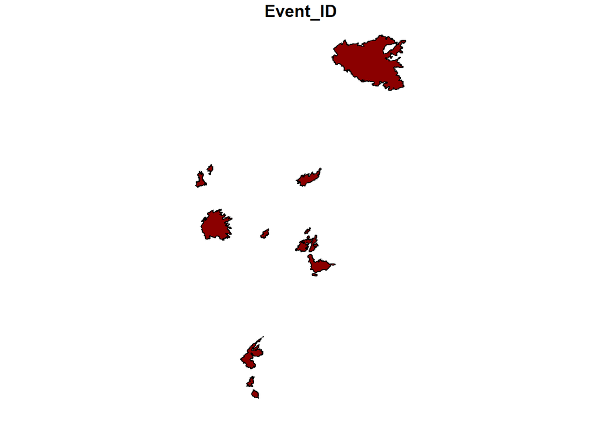

```r
plot(fire2.out[1], col="darkred") # fire 2
```

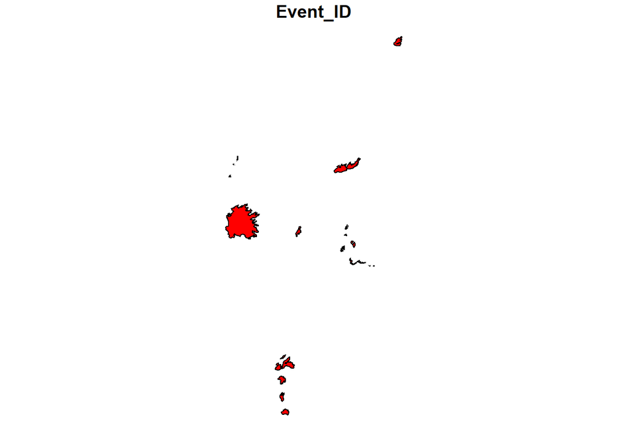

```r
plot(fire.intout[1], col="red") # reburn
```